# Data preprocessing for TRIPOD

Yuriko Harigaya, Nancy R. Zhang, Yuchao Jiang

2021-09-24

# 1 Introduction

This is a supplement to [the TRIPOD vignette](http://htmlpreview.github.io/?https://github.com/yharigaya/TRIPOD/blob/main/vignettes/TRIPOD.html). Here, we demonstrate data preprocessing required for conducting analysis using the TRIPOD package. The input is sigle-cell ATAC/RNA multiomic data, which is publicly available from [10x Genomics](https://support.10xgenomics.com/single-cell-multiome-atac-gex/datasets). The data was generated in 4881 cells of the mouse embryonic brain at day 18 and contains ATAC-seq and RNA-seq read counts for 144437 ATAC peaks and 32285 gene regions, respectively.

# 2 Required packages

The TRIPOD package is available from [GitHub](https://github.com/yharigaya/TRIPOD).

```r
if (!requireNamespace("devtools", quietly = TRUE)) install.packages("devtools")
devtools::install_github("yharigaya/TRIPOD/package")
```

```r
library(TRIPOD)
```

Additionally, the following packages are required to run this vignette.

```r
library(Seurat)
library(Signac)
library(GenomicRanges)
library(dplyr)
library(ggplot2)
library(EnsDb.Mmusculus.v79)
library(GenomeInfoDb)
library(patchwork)
library(BiocParallel)
library(chromVAR)
library(JASPAR2020)
library(TFBSTools)
library(motifmatchr)
library(BSgenome.Mmusculus.UCSC.mm10)
```

# 3 Preprocessing

## 3.1 Creating a Seurat object

We first create a Seurat object essentially according to the tutorial [here](https://satijalab.org/seurat/articles/weighted_nearest_neighbor_analysis.html). The input data (`e18_mouse_brain_fresh_5k_filtered_feature_bc_matrix.h5`, `e18_mouse_brain_fresh_5k_atac_fragments.tsv.gz`, and `e18_mouse_brain_fresh_5k_atac_fragments.tsv.gz.tbi`) can be downloaded from the 10x Genomics website [here](https://support.10xgenomics.com/single-cell-multiome-atac-gex/datasets).

In the following code, `"/path/to/your/hdf5/file"` needs to be replaced with the path to `e18_mouse_brain_fresh_5k_filtered_feature_bc_matrix.h5`.

```r
path <- "/path/to/your/hdf5/file"
```

The following code reads in the hdf5 file from 10x Genomics, which contains both RNA and ATAC-seq data.

```r
inputdata.10x <- Read10X_h5(path); rm(path)
```

```r
# extract RNA and ATAC data
rna.counts <- inputdata.10x$`Gene Expression`
atac.counts <- inputdata.10x$Peaks
```

We first create a Seurat object using the RNA-seq data.

```r
# create a Seurat object
e18 <- CreateSeuratObject(counts = rna.counts)
e18[["percent.mt"]] <- PercentageFeatureSet(e18, pattern = "^mt-")
```

```r
# select peaks in standard chromosomes
grange.counts <- StringToGRanges(rownames(atac.counts), sep = c(":", "-"))
grange.use <- seqnames(grange.counts) %in% standardChromosomes(grange.counts)
atac.counts <- atac.counts[as.vector(grange.use), ]
annotations <- GetGRangesFromEnsDb(ensdb = EnsDb.Mmusculus.v79)
seqlevelsStyle(annotations) <- "UCSC"
genome(annotations) <- "mm10"
```

In the following code, `"/path/to/your/atac/fragmenets/file"` needs to be replaced with the path to `e18_mouse_brain_fresh_5k_atac_fragments.tsv.gz`. The index file, `e18_mouse_brain_fresh_5k_atac_fragments.tsv.gz.tbi`, must be in the same directory.

```r
path <- "/path/to/your/atac/fragmenets/file"
```

```r
chrom.assay <- CreateChromatinAssay(
  counts = atac.counts, sep = c(":", "-"),
  genome = "mm10", fragments = path,
  min.cells = 10, annotation = annotations
); rm(path)
e18[["ATAC"]] <- chrom.assay
```

## 3.2 Adding cell type annotations (optional)

Although TRIPOD does not strictly require cell type information, it can substantially enrich the analysis. In our analysis, we use cell type annotation data obtained by transferring cell type labels from an independent scRNA-seq reference using SAVERCAT (Huang, Zhang, and Zhang 2020). We load the `label.severcat` data, which is included in the TRIPOD package, and add it to the Seurat object. Alternatively, the `label.seurat` data, which was obtained using Seurat V3 (Stuart et al. 2019), can be used.

```r
data(label.savercat)
e18$label.savercat <- label.savercat
```

## 3.3 Dimension reduction and visualization

Cell clustering and visualization give an informative overview of the data properties. For this purpose, we first perform pre-processing and dimensional reduction on the ATAC and RNA modalities independently according to [the Seurat tutorial](https://satijalab.org/seurat/articles/weighted_nearest_neighbor_analysis.html).

The following code normalizes the RNA-seq data, performs principal component analysis (PCA), and constructs a Uniform Manifold Approximation and Projection (UMAP) graph.

```r
# perform RNA analysis
DefaultAssay(e18) <- "RNA"
e18 <- SCTransform(e18, verbose = FALSE)
e18 <- RunPCA(e18)
e18 <- RunUMAP(e18, reduction = "pca", dims = 1:50,
    reduction.name = "umap.rna", reduction.key = "rnaUMAP_")
```

The following code normalizes the ATAC-seq data, performs partial singular value decomposition, and constructs a UMAP graph.

```r
# perform ATAC analysis
# exclude the first dimension as this is typically correlated with sequencing depth
DefaultAssay(e18) <- "ATAC"
e18 <- RunTFIDF(e18)
e18 <- FindTopFeatures(e18, min.cutoff = "q0")
e18 <- RunSVD(e18)
e18 <- RunUMAP(e18, reduction = "lsi", dims = 2:50,
    reduction.name = "umap.atac", reduction.key = "atacUMAP_")
```

Additionally, we calculate a weighted-nearest neighbor (WNN) graph, which represents a weighted combination of RNA and ATAC-seq modalities.

```r
# calculate a WNN graph
e18 <- FindMultiModalNeighbors(e18, reduction.list = list("pca", "lsi"),
    dims.list = list(1:50, 2:50))
e18 <- RunUMAP(e18, nn.name = "weighted.nn", reduction.name = "wnn.umap",
    reduction.key = "wnnUMAP_")
# e18 <- FindClusters(e18, graph.name = "wsnn", algorithm = 3, verbose = FALSE)
```

We then visualize the cell-type labels using color-coded UMAP plots based on RNA-seq data, ATAC-seq data, and the WNN analysis.

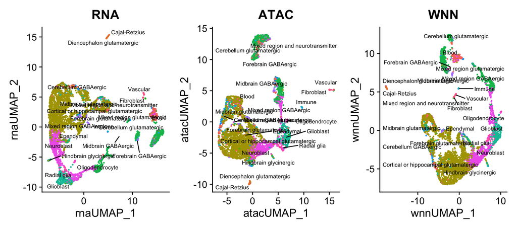

```r
p1 <- DimPlot(e18, reduction = "umap.rna",  group.by = "label.savercat",
    label = TRUE, label.size = 2.5, repel = TRUE) +
    ggtitle("RNA")
p2 <- DimPlot(e18, reduction = "umap.atac",  group.by = "label.savercat",
    label = TRUE, label.size = 2.5, repel = TRUE) +
    ggtitle("ATAC")
p3 <- DimPlot(e18, reduction = "wnn.umap", group.by = "label.savercat",
    label = TRUE, label.size = 2.5, repel = TRUE) +
    ggtitle("WNN")
p1 + p2 + p3 & NoLegend() & theme(plot.title = element_text(hjust = 0.5))
```

## 3.4 Filtering cells based on cell labels

Cell type labels can be used to filter the single cell data, which can, in turn, increase signal-to-noise ratio. We note that this procedure is inevitably subjective and that it is advisable to experiment with different filtering strategies. We merely illustrate an example case below, in which our basic goals are as follows.

- keep cells with biologically reasonable cell labels
- remove cells that belong to cell types with a small number of cells

We first examine the number of cells of each cell type.

```r
sort(table(e18$label.savercat), decreasing = TRUE)
```

```
#>
#> Cortical or hippocampal glutamatergic                   Forebrain GABAergic
#>                                  2333                                   708
#>                            Neuroblast                             Glioblast
#>                                   695                                   329
#>                                 Blood               Forebrain glutamatergic
#>                                   244                                   137
#>                Mixed region GABAergic                Midbrain glutamatergic
#>                                    91                                    86
#>                           Radial glia                         Cajal-Retzius
#>                                    65                                    38
#>                              Vascular                       Oligodendrocyte
#>                                    33                                    29
#>                 Hindbrain glycinergic                                Immune
#>                                    28                                    18
#>                            Fibroblast                             Ependymal
#>                                    12                                    10
#>                    Midbrain GABAergic                  Cerebellum GABAergic
#>                                    10                                     7
#>            Diencephalon glutamatergic              Cerebellum glutamatergic
#>                                     3                                     2
#>     Mixed region and neurotransmitter            Mixed region glutamatergic
#>                                     2                                     1
```

Based on the above information as well as existing biological knowledge, we focus on the seven cell types, “Cajal-Retzius,” “Cortical or hippocampal glutamatergic,” “Forebrain GABAergic,” “Glioblast,” Neuroblast, “Oligodendrocyte,” and “Radial glia.”

```r
# filter cells based on cell labels
celltypes.to.keep <- c("Cajal-Retzius",
    "Cortical or hippocampal glutamatergic",
  "Forebrain GABAergic", "Glioblast",
  "Neuroblast", "Oligodendrocyte", "Radial glia")
keep <- which(e18$label.savercat %in% celltypes.to.keep)
e18 <- subset(e18, cells = keep)
e18$celltype <- e18$label.savercat
e18$label.savercat <- NULL
```

For simplicity, we rename “Cortical or hippocampal glutamatergic” and “Forebrain GABAergic” as “Glutamatergic” and “GABAergic,” respectively.

```r
e18$celltype[e18$celltype == "Cortical or hippocampal glutamatergic"] <- "Glutamatergic"
e18$celltype[e18$celltype == "Forebrain GABAergic"] <- "GABAergic"
```

We convert the cell type data to factors and set the factor levels based on their developmental order (“Radial glia,” “Neuroblast,” “GABAergic,” “Glutamatergic,” “Glioblast,” “Oligodendrocyte,” and “Cajal-Retzius”).

```r
levels.celltype  <- c(
    "Radial glia", "Neuroblast",
    "GABAergic", "Glutamatergic",
    "Glioblast", "Oligodendrocyte",
    "Cajal-Retzius"
)
e18$celltype <- factor(e18$celltype, levels = levels.celltype)
```

## 3.5 Filtering cells based on sequencing depths

We then remove cells with low sequencing coverage or those with high proportions of mitochondrial reads, the latter of which is indicative of dying cells.

```r
e18 <- subset(
  x = e18,
  subset = nCount_ATAC < 1e5 &
    nCount_ATAC > 1e3 &
    nCount_RNA < 1e5 &
    nCount_RNA > 1e3 &
    percent.mt < 20
)
```

We then visualize the filtered data.

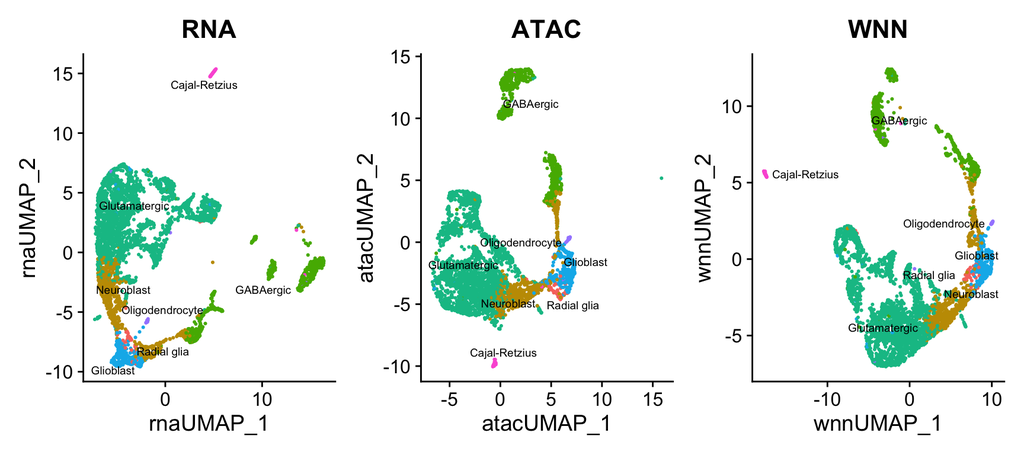

```r
p1 <- DimPlot(e18, reduction = "umap.rna", group.by = "celltype",
    label = TRUE, label.size = 2.5, repel = TRUE) +
    ggtitle("RNA")
p2 <- DimPlot(e18, reduction = "umap.atac", group.by = "celltype",
    label = TRUE, label.size = 2.5, repel = TRUE) +
    ggtitle("ATAC")
p3 <- DimPlot(e18, reduction = "wnn.umap", group.by = "celltype",
    label = TRUE, label.size = 2.5, repel = TRUE) +
    ggtitle("WNN")
p1 + p2 + p3 & NoLegend() & theme(plot.title = element_text(hjust = 0.5))
```

## 3.6 Run chromVAR

We next add TF motif information to the Seurat object according to the Signac tutorial [here](https://satijalab.org/signac/articles/motif_vignette.html).

```r
# create a motif object
pfm.set <- getMatrixSet(
    x = JASPAR2020,
    opts = list(species = 9606, all_versions = FALSE)) # human
```

In some cases, the TF motif information may not fully incorporate the existing knowledge in the literature. For example, in our analysis of the mouse embryonic brain data, we replace the motif for the Olig2 TF with `CAGCTG`, which has been validated by previous genetic and biochemical studies (Küspert et al. 2011).

For this purpose, we first construct a PFM of the Olig2 motif.

```r
pfm.olig2 <- PFMatrix(
    ID = "PFM.Olig2",
    name = "Olig2",
    strand = "+",
    bg = c(A = 0.25, C = 0.25, G = 0.25, T = 0.25),
  tags = list(
    species = "10090",
    tax_group = "vertebrates"),
    profileMatrix = matrix(
        c(0L,  1L, 0L,  0L,  0L,  0L, # A
        1L, 0L,  0L, 1L,  0L,  0L, # C
        0L,  0L,  1L,  0L, 0L,  1L, # G
        0L,  0L,  0L,  0L,  1L, 0L), # T
        byrow = TRUE, nrow = 4,
        dimnames=list(c("A", "C", "G", "T")))
)
```

The following code removes the original PFM of the Olig2 motif from the PFM set and adds the custom PFM.

```r
pfm.set <- pfm.set[-which(sapply(pfm.set, function(x) x@name == "OLIG2"))]
pfm.set$PFM.Olig2 <- pfm.olig2
```

The following code creates a motif matrix.

```r
motif.matrix <- CreateMotifMatrix(
  features = granges(e18),
  pwm = pfm.set,
  genome = "mm10",
  use.counts = FALSE
)
```

Once an optimal set of PFM is obtained, it can be added to the Seurat object using the following code.

```r
motif.object <- CreateMotifObject(data = motif.matrix, pwm = pfm.set)
e18 <- SetAssayData(e18, assay = "ATAC", slot = "motifs",
    new.data = motif.object)
e18 <- RunChromVAR(
  object = e18,
  genome = BSgenome.Mmusculus.UCSC.mm10
)
```

## 3.7 Creating objects required for model fitting

We then create objects containing information that is necessary for model fitting, namely, `transcripts.gr`, `peaks.gr`, `motifxTF`, and `peakxmotif`. See the documentation for more detailed descriptions of these objects.

The `transcripts.gr` object is a GRanges object from [the GenomicRanges package](https://bioconductor.org/packages/release/bioc/html/GenomicRanges.html) and contains chromosomal coordinates of annotated protein containing genes.

```r
DefaultAssay(e18) <- "ATAC"
transcripts.gr <- Signac:::CollapseToLongestTranscript(ranges = Annotation(e18))
transcripts.gr <- transcripts.gr[transcripts.gr$gene_biotype == "protein_coding"]
transcripts.gr <- transcripts.gr[seqnames(transcripts.gr) %in%
        paste("chr", 1:19, sep = "")]
transcripts.gr <- sort(transcripts.gr)
transcripts.gr
```

```
#> GRanges object with 20896 ranges and 3 metadata columns:
#>           seqnames            ranges strand |            gene_id   gene_biotype    gene_name
#>              <Rle>         <IRanges>  <Rle> |        <character>    <character>  <character>
#>       [1]     chr1   4807788-4848410      + | ENSMUSG00000025903 protein_coding       Lypla1
#>       [2]     chr1   4807892-4886770      + | ENSMUSG00000104217 protein_coding RP24-426M1.3
#>       [3]     chr1   4857814-4897909      + | ENSMUSG00000033813 protein_coding        Tcea1
#>       [4]     chr1   5070018-5162529      + | ENSMUSG00000033793 protein_coding      Atp6v1h
#>       [5]     chr1   5588466-5606131      + | ENSMUSG00000025905 protein_coding        Oprk1
#>       ...      ...               ...    ... .                ...            ...          ...
#>   [20892]    chr19 60837277-60861479      - | ENSMUSG00000063698 protein_coding        Sfxn4
#>   [20893]    chr19 60864051-60874556      - | ENSMUSG00000024997 protein_coding        Prdx3
#>   [20894]    chr19 61174686-61176309      - | ENSMUSG00000094649 protein_coding       Gm7102
#>   [20895]    chr19 61224402-61228418      - | ENSMUSG00000059326 protein_coding       Csf2ra
#>   [20896]    chr19 61296902-61297069      - | ENSMUSG00000095993 protein_coding      Gm21060
#>   -------
#>   seqinfo: 22 sequences from an unspecified genome; no seqlengths
```

The `peak.gr` object is a GRanges object from the GenomicRanges package and contains chromosomal coordinates of the ATAC peak regions in the multiomic data.

```r
peaks.gr <- e18@assays$ATAC@ranges
```

The `motifxTF` object is a matrix containing mapping between TFs and their binding motifs.

```r
motifxTF <- unlist(e18@assays$ATAC@motifs@motif.names)
motifxTF <- cbind(names(motifxTF), motifxTF)
colnames(motifxTF) <- c("motif", "TF")
```

The `peakxmotif` object is a binary sparse matrix containing indicators as to whether a given motif is preset in a given ATAC peak region.

```r
peakxmotif <- e18@assays$ATAC@motifs@data
peakxmotif[1:5, 1:5]
```

```
#> 5 x 5 sparse Matrix of class "dgCMatrix"
#>                      MA0030.1 MA0031.1 MA0051.1 MA0057.1 MA0059.1
#> chr1-3094399-3095523        .        .        .        .        .
#> chr1-3113503-3114077        1        1        1        .        .
#> chr1-3119414-3121804        1        .        .        .        .
#> chr1-3181343-3181401        .        .        .        .        .
#> chr1-3198296-3198611        .        .        .        .        .
```

```r
dim(peakxmotif)
```

```
#> [1] 139083    633
```

We then convert the human gene symbols to mouse counterparts.

```r
motifxTF[, 2] <- stringr::str_to_title(tolower(motifxTF[, 2]))
```

We only keep motifs when genes encoding corresponding TFs are present in the RNA-seq data.

```r
peakxmotif <- peakxmotif[, motifxTF[, 2] %in% rownames(e18@assays$RNA)]
motifxTF <- motifxTF[motifxTF[, 2] %in% rownames(e18@assays$RNA), ]
```

We note that our current implementation excludes cases where a TF corresponds to multiple motifs or vice versa. We plan to provide an option to include such degenerate cases in a future version of the package.

## 3.8 Further filering of the data

Since the normalization step (SCTranform) do not return values for all input, we perform further data filtering to ensure that the same set of genes is included in all objects.

```r
# take the intersection of the genes
genes <- intersect(transcripts.gr$gene_name, rownames(e18@assays$SCT))
DefaultAssay(e18) <- "RNA"
e18@assays$RNA <- subset(e18@assays$RNA,
    features = match(genes, rownames(e18@assays$RNA)))
e18@assays$SCT <- subset(e18@assays$SCT,
    features = match(genes, rownames(e18@assays$SCT)))
transcripts.gr <- transcripts.gr[match(genes, transcripts.gr$gene_name)]
peakxmotif <- peakxmotif[, motifxTF[, 2] %in% genes]
motifxTF <- motifxTF[motifxTF[, 2] %in% genes, ]
e18@assays$chromvar <- subset(
    e18@assays$chromvar,
    features = match(motifxTF[, 1], rownames(e18@assays$chromvar)))
```

We then perform normalization and dimension reduction again for the filtered data.

```r
# perform re-normalization
# RNA analysis
DefaultAssay(e18) <- "RNA"
e18 <- SCTransform(e18, verbose = FALSE)
e18 <- RunPCA(e18)
e18 <- RunUMAP(e18, reduction = "pca", dims = 1:50,
    reduction.name = "umap.rna", reduction.key = "rnaUMAP_")

# ATAC analysis
DefaultAssay(e18) <- "ATAC"
e18 <- RunTFIDF(e18)
e18 <- FindTopFeatures(e18, min.cutoff = "q0")
e18 <- RunSVD(e18)
e18 <- RunUMAP(e18, reduction = "lsi", dims = 2:50,
    reduction.name = "umap.atac", reduction.key = "atacUMAP_")

# recalculate a WNN graph
e18 <- FindMultiModalNeighbors(e18, reduction.list = list("pca", "lsi"),
    dims.list = list(1:50, 2:50))
e18 <- RunUMAP(e18, nn.name = "weighted.nn",
    reduction.name = "wnn.umap", reduction.key = "wnnUMAP_")
e18 <- FindClusters(e18, graph.name = "wsnn",
  algorithm = 3, verbose = FALSE) # this may not be necessary
```

The following code visualizes the data on recalculated graphs.

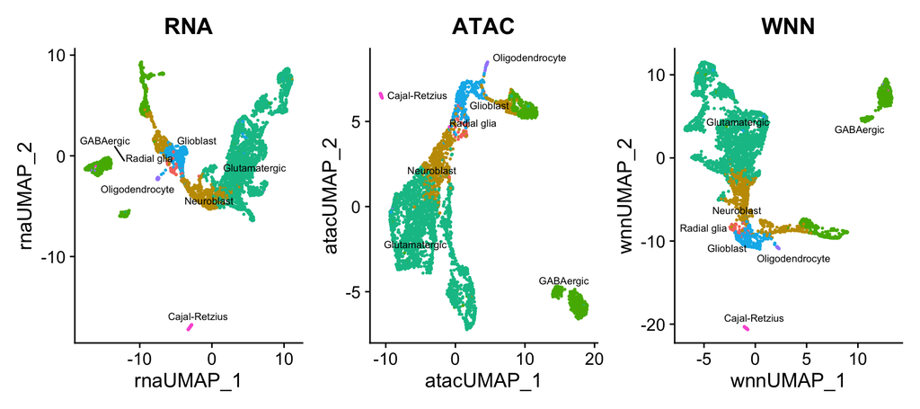

```r
p1 <- DimPlot(e18, reduction = "umap.rna",  group.by = "celltype",
    label = TRUE, label.size = 2.5, repel = TRUE) +
    ggtitle("RNA")
p2 <- DimPlot(e18, reduction = "umap.atac",  group.by = "celltype",
    label = TRUE, label.size = 2.5, repel = TRUE) +
    ggtitle("ATAC")
p3 <- DimPlot(e18, reduction = "wnn.umap", group.by = "celltype",
    label = TRUE, label.size = 2.5, repel = TRUE) +
    ggtitle("WNN")
p1 + p2 + p3 & NoLegend() & theme(plot.title = element_text(hjust = 0.5))
```

## 3.9 Partitioning single cells into metacells

To alleviate the issue of sparsity of the single cell data, we next partition the cells into clusters, which we call metacells. The models in the TRIPOD package are based on metacells, not single cells. Cells can be clustered based on either the ATAC or RNA modality. It is also possible to use the weighted nearest neighbor (WNN) method (Hao et al. 2021). For the mouse embyonic barin data, we use the RNA modality (see above).

To obtain a set of metacells suited for model fitting, it is necessary to select an optimal resolution of clustering to ensure the following.

- a sufficient number of cells per metacell for resolving the sparsity issue
- a sufficient number of metacells to allow for model fitting

Our empirical approach is to select a resolution that gives 80 or more metacells, the majority of which contain 20 or more single cells. For this purpose, we first construct a shared nearest neighbor graph.

```r
# get rna meta-cells by clustering cells on basis of their scRNA-seq profiles
DefaultAssay(e18) <- "SCT"
e18 <- FindNeighbors(e18, reduction = "pca", dims = 1:30)
```

Based on the graph, we then perform clustering at several resolutions. The following code generates a data frame containing the resolutions, the number of resultant clusters, and the number of clusters with fewer than threshold number of single cells. The threshold is set to 20 cells.

```r
num.clusters <- optimizeResolution(
    object = e18,
    graph.name = "SCT_snn",
    assay.name = "SCT",
    resolutions = seq(10, 35, 5),
    min.num = 20
)
num.clusters
```

```
#>   resolution num_clusters num_below
#> 1         10           66         0
#> 2         15           87         1
#> 3         20          102         7
#> 4         25          125        16
#> 5         30          142        24
#> 6         35          164        45
```

Based on the above analysis, we select the resolution of 15.

```r
res <- 15
e18 <- FindClusters(e18, graph.name = "SCT_snn",
        resolution = res, verbose = FALSE)
```

In our procedure, the factor levels need to be in an ascending numerical order. The following code shows that the ordering is not desirable.

```r
levels(e18$SCT_snn_res.15)
```

```
#>  [1] "0"  "1"  "10" "11" "12" "13" "14" "15" "16" "17" "18" "19" "2"  "20" "21" "22" "23" "24" "25" "26"
#> [21] "27" "28" "29" "3"  "30" "31" "32" "33" "34" "35" "36" "37" "38" "39" "4"  "40" "41" "42" "43" "44"
#> [41] "45" "46" "47" "48" "49" "5"  "50" "51" "52" "53" "54" "55" "56" "57" "58" "59" "6"  "60" "61" "62"
#> [61] "63" "64" "65" "66" "67" "68" "69" "7"  "70" "71" "72" "73" "74" "75" "76" "77" "78" "79" "8"  "80"
#> [81] "81" "82" "83" "84" "85" "86" "9"
```

We reorder the factor levels using the following code.

```r
tmp <- as.character(e18$SCT_snn_res.15)
levels.15 <- as.character(sort(as.numeric(levels(e18$SCT_snn_res.15))))
tmp <- factor(tmp, levels = levels.15)
e18$SCT_snn_res.15 <- tmp
levels(e18$SCT_snn_res.15)
```

```
#>  [1] "0"  "1"  "2"  "3"  "4"  "5"  "6"  "7"  "8"  "9"  "10" "11" "12" "13" "14" "15" "16" "17" "18" "19"
#> [21] "20" "21" "22" "23" "24" "25" "26" "27" "28" "29" "30" "31" "32" "33" "34" "35" "36" "37" "38" "39"
#> [41] "40" "41" "42" "43" "44" "45" "46" "47" "48" "49" "50" "51" "52" "53" "54" "55" "56" "57" "58" "59"
#> [61] "60" "61" "62" "63" "64" "65" "66" "67" "68" "69" "70" "71" "72" "73" "74" "75" "76" "77" "78" "79"
#> [81] "80" "81" "82" "83" "84" "85" "86"
```

We then overwrite the `seurat_cluster` column with the `SCT_snn_res.15` column.

```r
e18@meta.data$seurat_clusters <- e18@meta.data$SCT_snn_res.15
e18@meta.data$SCT_snn_res.15 <- NULL
```

We now obtain matrices containing normalized RNA expression and chromatin accessibility per metacell using the `getMetacellMatrix` function.

```r
metacell.rna <- getMetacellMatrix(
    object = e18,
  cluster = "seurat_clusters",
    assay = "RNA")

metacell.peak <- getMetacellMatrix(
    object = e18,
  cluster = "seurat_clusters",
    assay = "ATAC")
```

We then remove metacell clusters with fewer than 20 cells from the matrices as well as cells in the removed metacell clusters from the Seurat object.

```r
# remove metacell clusters with fewer than 20 cells
remove <- as.vector(table(e18$seurat_clusters)) < 20
names.remove <- names(table(e18$seurat_clusters))[remove]
metacell.rna <- metacell.rna[!remove, ]
metacell.peak <- metacell.peak[!remove, ]

# remove cells in the removed metacell clusters from the Seurat object
e18 <- e18[, !(e18$seurat_clusters %in% names.remove)]
e18$seurat_clusters <- droplevels(e18$seurat_clusters)
```

It is necessary to save the Seurat object (`e18`) for running [the TRIPOD vignette](http://htmlpreview.github.io/?https://github.com/yharigaya/TRIPOD/blob/main/vignettes/TRIPOD.html) since the object is not included in the TRIPOD package.

```r
file <- "e18.rds"
path <- file.path("path/to/your/dir", file)
saveRDS(e18, path); rm(path)
```

## 3.10 Assigning cell types and colors for visualization

For visualization purposes, it is convenient to assign colors to cell types and create objects storing mapping between them. For this purpose, we first assign cell types to metacells.

```r
metacell.celltype <- getCellTypeForMetacell(e18,
    celltype.col.name = "celltype", cluster.col.name = "seurat_clusters")
```

We then assign colors to cell types. The following code generates a mapping between cell types and colors for single cells.

```r
sc.color.map <- getColorsForSingleCells(
    object = e18, reduction = "umap.rna", celltype.col.name = "celltype")
head(sc.color.map)
```

```
#>                         celltype   color
#> AAACAGCCAACCGCCA-1 Glutamatergic #00C094
#> AAACAGCCAAGGTCGA-1     Glioblast #00B6EB
#> AAACAGCCATCAGCAC-1 Cajal-Retzius #FB61D7
#> AAACAGCCATGGTTAT-1 Glutamatergic #00C094
#> AAACATGCACTTACAG-1 Glutamatergic #00C094
#> AAACCAACAACTGGGA-1    Neuroblast #C49A00
```

The following code creates a mapping between cell types and colors for metacells.

```r
metacell.color.map <- getColorsForMetacells(
    metacell.celltype = metacell.celltype, sc.color.map = sc.color.map)
head(metacell.color.map)
```

```
#>        celltype   color
#> 1 Glutamatergic #00C094
#> 2 Glutamatergic #00C094
#> 3     GABAergic #53B400
#> 4     Glioblast #00B6EB
#> 5     GABAergic #53B400
#> 6 Glutamatergic #00C094
```

It is also convenient to have a mapping between cell types and colors themselves.

```r
color.map <- getColors(ordered.celltypes = levels(e18$celltype),
    metacell.color.map = metacell.color.map)
color.map
```

```
#>          celltype   color
#> 1     Radial glia #F8766D
#> 2      Neuroblast #C49A00
#> 3       GABAergic #53B400
#> 4   Glutamatergic #00C094
#> 5       Glioblast #00B6EB
#> 6 Oligodendrocyte #A58AFF
#> 7   Cajal-Retzius #FB61D7
```

## 3.11 Getting a list of target genes

We typically run model fitting for top-ranked highly variable genes (HVGs) identified by Seurat. The following code gives a ordered list of top 3000 HVGs.

```r
# obtain highly variable genes based on SCT
DefaultAssay(e18) <- "SCT"
head(VariableFeatures(e18))
```

```
#> [1] "Nrxn3"  "Erbb4"  "Nxph1"  "Adarb2" "Hs3st4" "Tnc"
```

```r
length(VariableFeatures(e18))
```

```
#> [1] 3000
```

```r
hvg <- VariableFeatures(e18)
```

# References

Hao, Yuhan, Stephanie Hao, Erica Andersen-Nissen, William M. Mauck, Shiwei Zheng, Andrew Butler, Maddie J. Lee, et al. 2021. “Integrated Analysis of Multimodal Single-Cell Data.” *Cell* 184 (June): 3573–3587.e29. https://doi.org/10.1016/j.cell.2021.04.048.

Huang, Mo, Zhaojun Zhang, and Nancy R. Zhang. 2020. “Dimension Reduction and Denoising of Single-Cell RNA Sequencing Data in the Presence of Observed Confounding Variables,” August. https://doi.org/10.1101/2020.08.03.234765.

Küspert, Melanie, Alexander Hammer, Michael R. Bösl, and Michael Wegner. 2011. “Olig2 Regulates Sox10 Expression in Oligodendrocyte Precursors Through an Evolutionary Conserved Distal Enhancer.” *Nucleic Acids Research* 39 (March): 1280–93. https://doi.org/10.1093/nar/gkq951.

Stuart, Tim, Andrew Butler, Paul Hoffman, Christoph Hafemeister, Efthymia Papalexi, William M. Mauck, Yuhan Hao, Marlon Stoeckius, Peter Smibert, and Rahul Satija. 2019. “Comprehensive Integration of Single-Cell Data.” *Cell* 177 (June): 1888–1902.e21. https://doi.org/10.1016/j.cell.2019.05.031.